# Table of Contents

```python
import matplotlib.pyplot as plt
import pandas
```

```python
import quandl # https://github.com/quandl/quandl-python#configuration
api_key = 'qVwroBWLG9jq9C4THLB'
```

# Fetch the daily returns for a stock

```python
import pandas_datareader.data as web

symbol = 'FB'
FB = web.DataReader(symbol, 'yahoo', start='2015-07-04', end='2017-07-04')
FB.tail()
```

| Date | High | Low | Open | Close | Volume | Adj Close |
| --- | --- | --- | --- | --- | --- | --- |
| 2017-06-27 | 153.309998 | 150.389999 | 152.839996 | 150.580002 | 19360800 | 150.580002 |
| 2017-06-28 | 153.470001 | 149.860001 | 150.919998 | 153.240005 | 16719100 | 153.240005 |
| 2017-06-29 | 152.500000 | 148.919998 | 152.279999 | 151.039993 | 23973500 | 151.039993 |
| 2017-06-30 | 151.919998 | 150.059998 | 151.899994 | 150.979996 | 17666000 | 150.979996 |
| 2017-07-03 | 152.149994 | 147.800003 | 151.720001 | 148.429993 | 13862700 | 148.429993 |

# Fetch the daily returns from quandle directly

```python
import quandl
df = quandl.get('EOD/BA.1', api_key = api_key) # we can just give .1 .2 to select perticular columns
```

# Import benchmark

```python
symbol = '^GSPC' # s&p500
SPY = web.DataReader(symbol, 'yahoo', start='2015-07-04', end='2017-07-04')
SPY.tail()
```

| Date | High | Low | Open | Close | Volume | Adj Close |
| --- | --- | --- | --- | --- | --- | --- |
| 2017-06-27 | 2440.149902 | 2419.379883 | 2436.340088 | 2419.379883 | 3563910000 | 2419.379883 |
| 2017-06-28 | 2442.969971 | 2428.020020 | 2428.699951 | 2440.689941 | 3500800000 | 2440.689941 |
| 2017-06-29 | 2442.729980 | 2405.699951 | 2442.379883 | 2419.699951 | 3900280000 | 2419.699951 |
| 2017-06-30 | 2432.709961 | 2421.649902 | 2429.199951 | 2423.409912 | 3361590000 | 2423.409912 |
| 2017-07-03 | 2439.169922 | 2428.689941 | 2431.389893 | 2429.010010 | 1962290000 | 2429.010010 |

# Preliminary plots

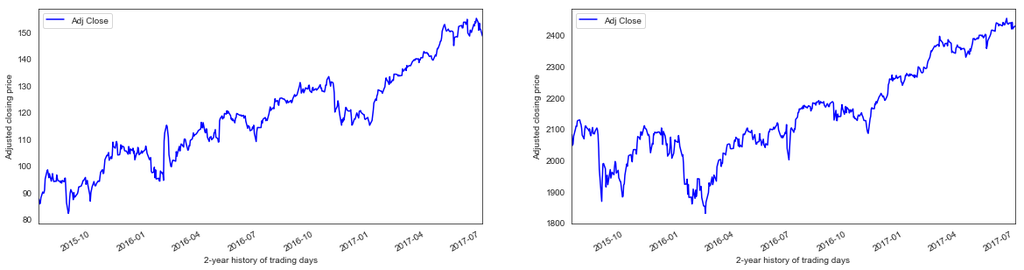

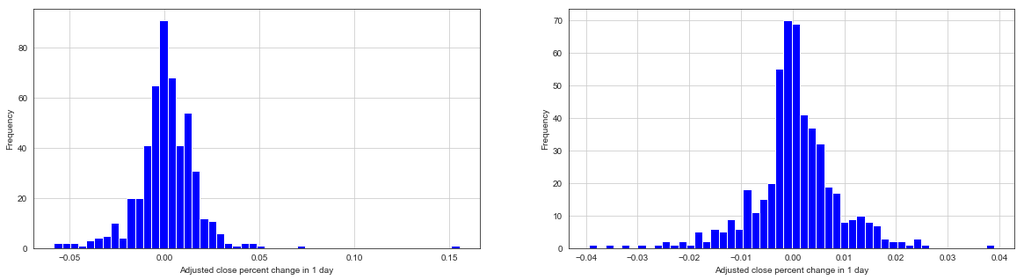

```python
import seaborn as sns
sns.set_style('white', {"xtick.major.size": 2, "ytick.major.size": 2})
flatui = ["#9b59b6", "#3498db", "#95a5a6", "#e74c3c", "#34495e", "#2ecc71","#f4cae4"]
sns.set_palette(sns.color_palette(flatui,7))

df_list = [FB,SPY]

fig, ax = plt.subplots(nrows=1,ncols=2,figsize=(20,5))
for index, ax in enumerate(ax):
    df_list[index]['Adj Close'].plot(label='Adj Close', color='b', legend=True, ax=ax)
    ax.set_xlabel('2-year history of trading days')
    ax.set_ylabel('Adjusted closing price')

fig, ax = plt.subplots(nrows=1,ncols=2,figsize=(20,5))
for index, ax in enumerate(ax):
    df_list[index]['Adj Close'].pct_change().hist(bins=50, color = 'b', ax=ax)
    ax.set_xlabel('Adjusted close percent change in 1 day')
    ax.set_ylabel('Frequency')
```

# Moving Averages

## Exponential Moving Averages

Our exploratory data analysis we plotted the raw data, which is noisy. Moving averages filter out day-to-day noise in order to find trends. An **exponential moving average** can be constructed by chaining together two pandas methods:

- `.ewm()`, the pandas method for **exponential weighted functions**, includes an option for a non-negative decay term `com`, 1/(1 + `com`);
- `.mean()`, the method for computing mean.

To compute the moving average of the adjusted closing price for a single stock, the following function can be used:

```python
import numpy
```

This simple code plots 14 day exponential moving average for closing prices of FB stock

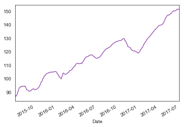

```python
FB['Adj Close'].ewm(14).mean().plot()
```

```python
def EWMA(stock_list, days_list, name_list):
    from itertools import cycle
    color = cycle('grc')

    for index,stock in enumerate(stock_list):
        fig, ax = plt.subplots(figsize=(20,6))
        stock['Adj Close'].plot(title = name_list[index], label= 'Adj Close', color='b', legend=True, ax=ax)
        for day in days_list:
            stock['Adj Close'].ewm(com=day).mean().plot(label= 'ewma_' + str(day) + 'day', color= next(color), legend=True, ax=ax)
            ax.set_xlabel('trading days')
            ax.set_ylabel('price')
```

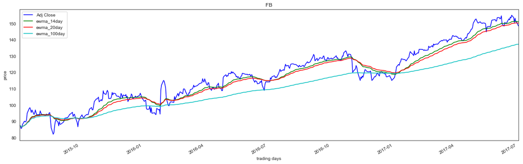

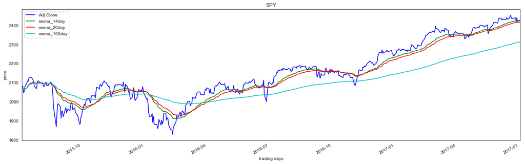

```python
# call the funtion by passing stocks,their names and days ewma required
EWMA(stock_list = [FB,SPY], name_list = ['FB','SPY'], days_list = [14,20,100])
```

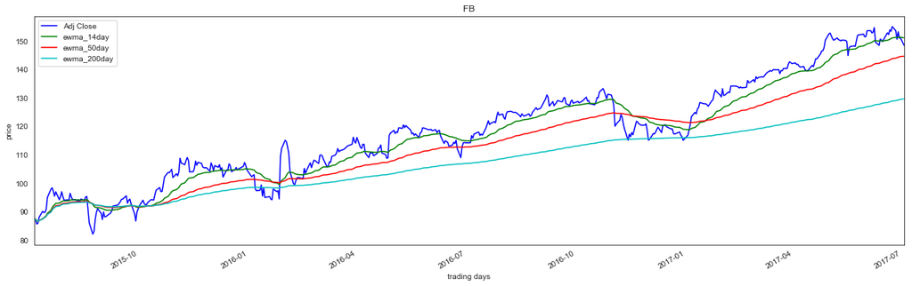

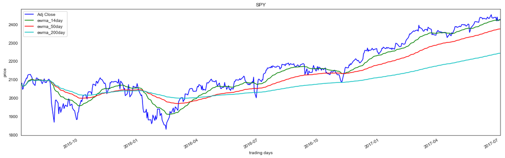

```python
EWMA(stock_list = [FB,SPY], name_list = ['FB','SPY'],days_list = [14,50,200])
```

# Relative strength and Relative Strength Index

Relative strength index

From **Wikipedia**

The relative strength index (RSI) is a technical indicator used in the analysis of financial markets. It is intended to chart the current and historical strength or weakness of a stock or market based on the closing prices of a recent trading period. The indicator should not be confused with relative strength.

The RSI is classified as a momentum oscillator, measuring the velocity and magnitude of directional price movements. Momentum is the rate of the rise or fall in price. The RSI computes momentum as the ratio of higher closes to lower closes: stocks which have had more or stronger positive changes have a higher RSI than stocks which have had more or stronger negative changes.

The RSI is most typically used on a 14-day timeframe, measured on a scale from 0 to 100, with high and low levels marked at 70 and 30, respectively. Shorter or longer timeframes are used for alternately shorter or longer outlooks. More extreme high and low levels—80 and 20, or 90 and 10—occur less frequently but indicate stronger momentum.

The relative strength index was developed by J. Welles Wilder and published in a 1978 book, New Concepts in Technical Trading Systems, and in Commodities magazine (now Futures magazine) in the June 1978 issue.It has become one of the most popular oscillator indices.

The RSI provides signals that tell investors to buy when the security or currency is oversold and to sell when it is overbought.

RSI in longer time is usually overcome by the simple buy-and-hold strategy.

$$ RSI_n = 100 - \frac{100}{1+RS_n} $$

For each trading period an upward change U or downward change D is calculated. Up periods are characterized by the close being higher than the previous close:

$$ U = close_{now} - close_{previous} $$$$ D=0 $$

Conversely, a down period is characterized by the close being lower than the previous period's close (note that D is nonetheless a positive number),

$$ U=0 $$$$ D = close_{previous} -close_{now} $$$$ RS_n = \frac{SMMA(U,n)}{SMMA(D,n)} $$

where $n$ is set by the argument `period` passed from when the function is called. The default is `period = "14"`.

If the last close is the same as the previous, both U and D are zero. The average U and D are calculated using an n-period smoothed or modified moving average (SMMA or MMA) which is an exponentially smoothed Moving Average with α = 1/period. Some commercial packages, like AIQ, use a standard exponential moving average (EMA) as the average instead of Wilder's SMMA.

**Principles** Wilder posited that when price moves up very rapidly, at some point it is considered overbought. Likewise, when price falls very rapidly, at some point it is considered oversold. In either case, Wilder deemed a reaction or reversal imminent.

The level of the RSI is a measure of the stock's recent trading strength. The slope of the RSI is directly proportional to the velocity of a change in the trend. The distance traveled by the RSI is proportional to the magnitude of the move.

Wilder believed that tops and bottoms are indicated when RSI goes above 70 or drops below 30. Traditionally, RSI readings greater than the 70 level are considered to be in overbought territory, and RSI readings lower than the 30 level are considered to be in oversold territory. In between the 30 and 70 level is considered neutral, with the 50 level a sign of no trend.

```python
def RSI(stock, column="Adj Close", period=14):
    # Wilder's RSI
    close = stock[column]
    delta = close.diff()
    up, down = delta.copy(), delta.copy()

    up[up < 0] = 0
    down[down > 0] = 0

    # Calculate the exponential moving averages (EWMA)
    roll_up = up.ewm(com=period - 1, adjust=False).mean()
    roll_down = down.ewm(com=period - 1, adjust=False).mean().abs()

    # Calculate RS based on exponential moving average (EWMA)
    rs = roll_up / roll_down   # relative strength =  average gain/average loss

    rsi = 100-(100/(1+rs))
    stock['RSI'] = rsi

    return stock
```

```python
RSI(FB).head(15)
```

| Date | High | Low | Open | Close | Volume | Adj Close | RSI |
| --- | --- | --- | --- | --- | --- | --- | --- |
| 2015-07-06 | 88.190002 | 86.389999 | 86.489998 | 87.550003 | 24635900 | 87.550003 | NaN |
| 2015-07-07 | 87.849998 | 85.230003 | 87.800003 | 87.220001 | 33059900 | 87.220001 | 0.000000 |
| 2015-07-08 | 86.750000 | 85.449997 | 86.290001 | 85.650002 | 24399300 | 85.650002 | 0.000000 |
| 2015-07-09 | 87.599998 | 85.650002 | 86.730003 | 85.879997 | 23307400 | 85.879997 | 4.055328 |
| 2015-07-10 | 88.220001 | 86.769997 | 87.349998 | 87.949997 | 23245900 | 87.949997 | 31.126779 |
| 2015-07-13 | 90.220001 | 88.419998 | 88.660004 | 90.099998 | 29976700 | 90.099998 | 47.649012 |
| 2015-07-14 | 90.800003 | 89.650002 | 90.459999 | 89.680000 | 26627800 | 89.680000 | 45.359816 |
| 2015-07-15 | 90.989998 | 89.419998 | 90.000000 | 89.760002 | 30886600 | 89.760002 | 45.893052 |
| 2015-07-16 | 90.860001 | 89.769997 | 90.279999 | 90.849998 | 21804100 | 90.849998 | 52.670263 |
| 2015-07-17 | 95.389999 | 92.540001 | 92.550003 | 94.970001 | 54001600 | 94.970001 | 68.652999 |
| 2015-07-20 | 98.599998 | 95.360001 | 95.849998 | 97.910004 | 54860500 | 97.910004 | 75.111724 |
| 2015-07-21 | 99.239998 | 97.139999 | 98.949997 | 98.389999 | 39453300 | 98.389999 | 75.981816 |
| 2015-07-22 | 97.580002 | 95.919998 | 96.739998 | 97.040001 | 28299500 | 97.040001 | 68.706545 |
| 2015-07-23 | 97.449997 | 94.809998 | 96.959999 | 95.440002 | 29418800 | 95.440002 | 61.224264 |
| 2015-07-24 | 97.760002 | 95.879997 | 97.349998 | 96.949997 | 33444900 | 96.949997 | 65.088350 |

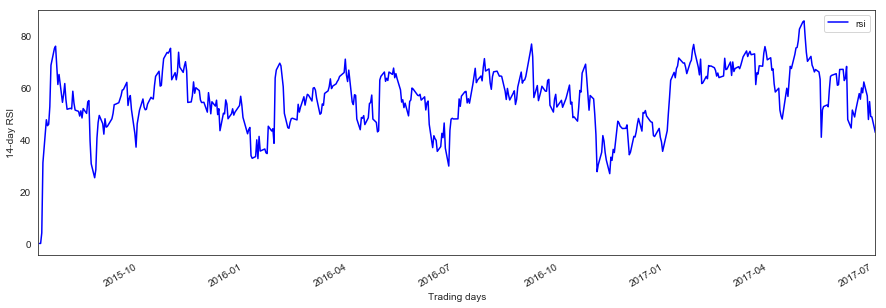

```python
fig,ax=plt.subplots(figsize=(15,5))
FB.RSI.plot(ax=ax, label='rsi', legend=True, color='b');
ax.set_xlabel('Trading days'); ax.set_ylabel('14-day RSI');
```